# Homework 1

Mert Nardal

12 04 2022

# Visualisation and Analysis of 3 Different Time Series Data and related Google Trends

## Introduction

In this report, three different time series data and three different google trends data for specific keywords that is considered as related with the three different time series data, is obtained. All the six data sets are time series between 2010 January and 2022 January in monthly basis. Then the correlation between these 3 time series and their related google trends data is examined separately. After that, correlations between USD/TRY Exchange Rate-Interest Rate and USD/TRY Exchange Rate-CPI index are examined. The data sets in this report are:

1. US Dollar/Turkish Lira Exchange Rate
2. Interest Rate for Turkish Lira Accounts
3. General CPI Index
4. Google Trends of “dolar”
5. Google Trends of “enflasyon”
6. Google Trends of “faiz”

## 1) USD/TRY Exchange Rate and Google Trends for keyword “dolar”

### USD/TRY Exchange Rate Over Time

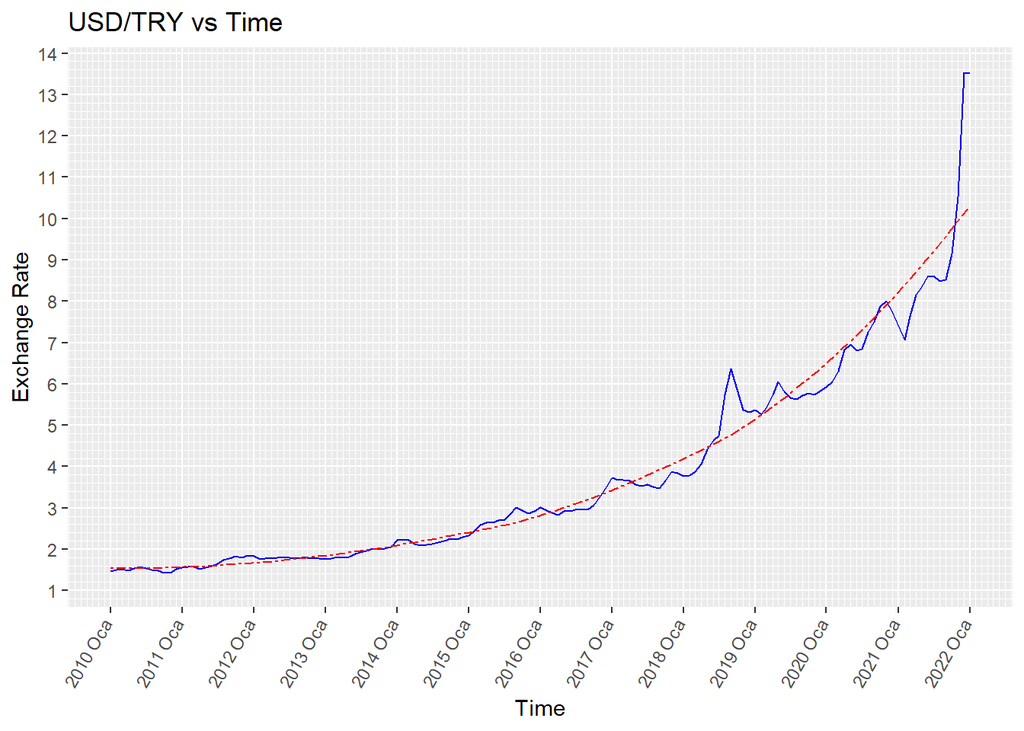

It can be said that exchange rate has an increasing trend over time. Although there are fluctuations from 2018 May to mid 2021 the increasing trend still remains. The reason for fluctuations in 2018 are elections in Turkey then dolar increases until 2019 again then fluctuations begin at 2020 again which caused by covid period and its effects on economy. The google trend keyword is “dolar” for USD/TRY exchange rate data because google shows the USD/TRY exchange rate when somebody searches “dolar”.Therefore a correlation may exist between these two data sets. Boxplots, which are able to provide the information about how the data distributed, are preferred to visualize the USD/TRY exchange rate to make better analysis.

### Boxplots of USD/TRY Exchange Rate Over Time grouped by years

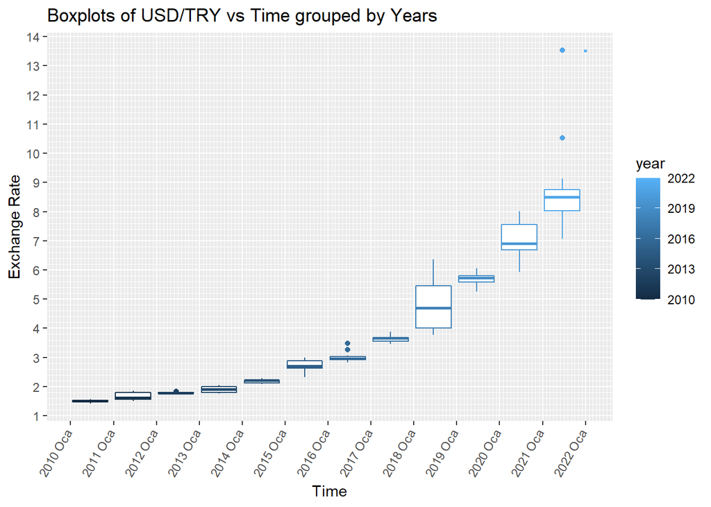

### Google Trends for keyword “dolar”

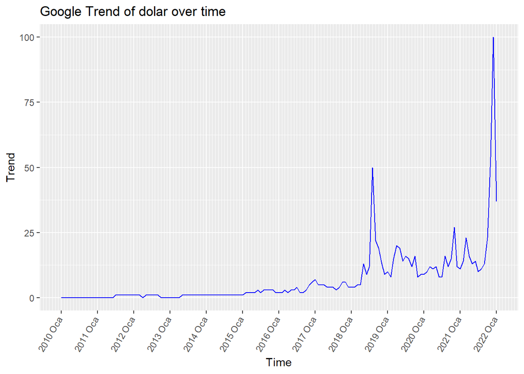

In the Google Trends graph trend is low and stable between 2010-2018. After 2018 trends are higher and more fluctuating, the biggest jumps occur when 2018-2019 and 2021-2022. Also, in the USD/TRY graph the boxes are bigger (which means the USD/TRY exchange rate has a high variance or change more frequently ) in 2018-2019 and 2021-2022. Moreover, the low trends in years 2010-2018 corresponds to small boxes (which means USD/TRY exchange rate is more stable or has a low variance) in the exchange rate boxplot graph. After analyzing these graphs, it can be said that people tend to search the exchange rates more often if the exchange rate is unstable. An explanation for this situation may be the fact that people can make financial gains by buying and selling dollars when exchange rate change more frequently. Also the companies that uses both Turkish Lira and US dollars may suffer from financial losses due to the unstability of the exchange rates if they don’t check the exchange rates of the currencies that they used more frequently.

## 2) General CPI Index and Google Trends for keyword “enflasyon”

### CPI Index change over time

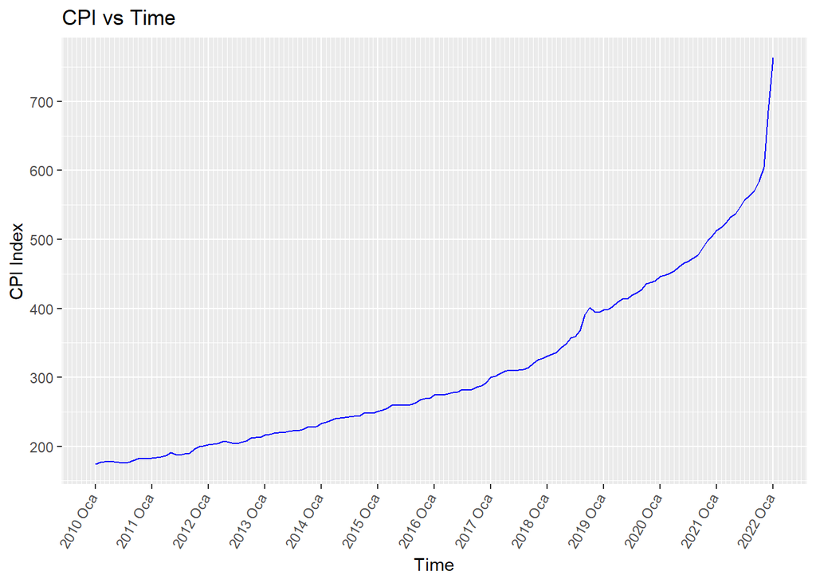

CPI index is a measure to worth of some specific goods. It is calculated (price of good at year t) / (price of goods in base year). Difference of CPI indexes are used to calculate inflation rate. Since negative inflation is an extremely rare situation, CPI index usually has an increasing trend over time. A smooth growth in CPI over time in Turkey can be seen on the graph. For Google Trends the keyword “enflasyon” is choosed. Since CPI is an indicator for inflation, changes in CPI can affect the searches of “enflasyon”.

### Boxplots of CPI Index grouped by year

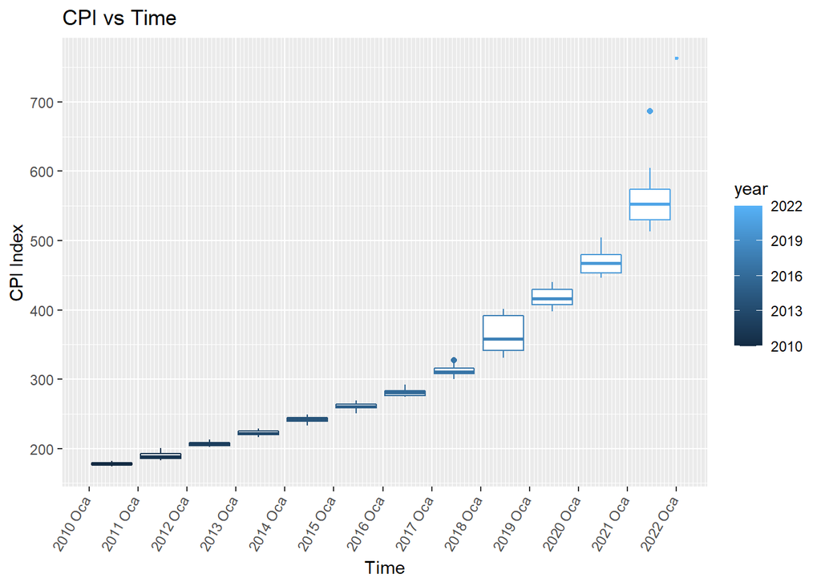